# Forecasting Equity Market Trends and Volatility using Meta’s Prophet Model

## Prophet Model – VIX Forecast

```r
vix_model <- prophet(vix_data)
```

```
## Disabling daily seasonality. Run prophet with daily.seasonality=TRUE to override this.
```

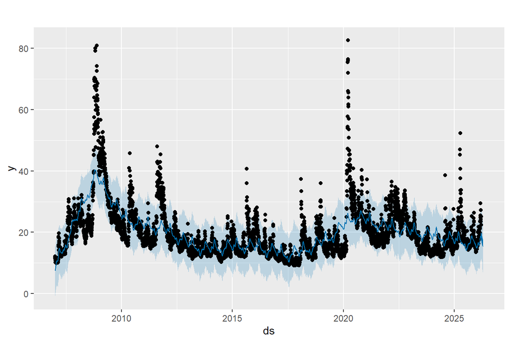

```r
vix_future <- make_future_dataframe(vix_model, periods = 30)
vix_forecast <- predict(vix_model, vix_future)
plot(vix_model, vix_forecast)
```

## Explanation

A future dataframe extending 30 days ahead was created, and forecasts were generated based on the historical VIX data. Unlike ES prices, the VIX does not follow a smooth long-term trend but instead exhibits sudden spikes during periods of market stress.

One limitation I noticed while working with this data is that the VIX can spike very suddenly, which makes it difficult for models like Prophet to capture extreme market events accurately.

Nonetheless, the Prophet model provides a useful framework for modelling volatility, although sudden market shocks remain difficult to predict accurately.

## Comparison of ES and VIX

The comparison between ES futures and the VIX highlights a clear inverse relationship between equity market performance and volatility. While the ES series generally follows a long-term upward trend, the VIX tends to remain low during stable periods and spike sharply during market downturns.

This relationship is particularly evident during periods of financial stress. For example, during the 2020 COVID-19 market crash, ES prices declined significantly while the VIX surged to extreme levels. This clearly shows that when equity prices fall, volatility tends to rise, reflecting increased uncertainty and risk in the market.

From the forecasting results, the ES model captures gradual trends in market prices, whereas the VIX model reflects the irregular and reactive nature of volatility. Together, these models provide complementary insights: ES indicates market direction, while the VIX reflects the level of risk and uncertainty.And from a trading perspective, this relationship is particularly useful, as rising volatility often signals increased uncertainty and potential risk in the market. Understanding this relationship is valuable for traders and analysts, as combining both indicators can improve decision-making and provide a more complete view of market conditions. Suggesting that incorporating volatility measures such as the VIX into price forecasting models may improve predictive performance.

## Combined Analysis of ES and VIX

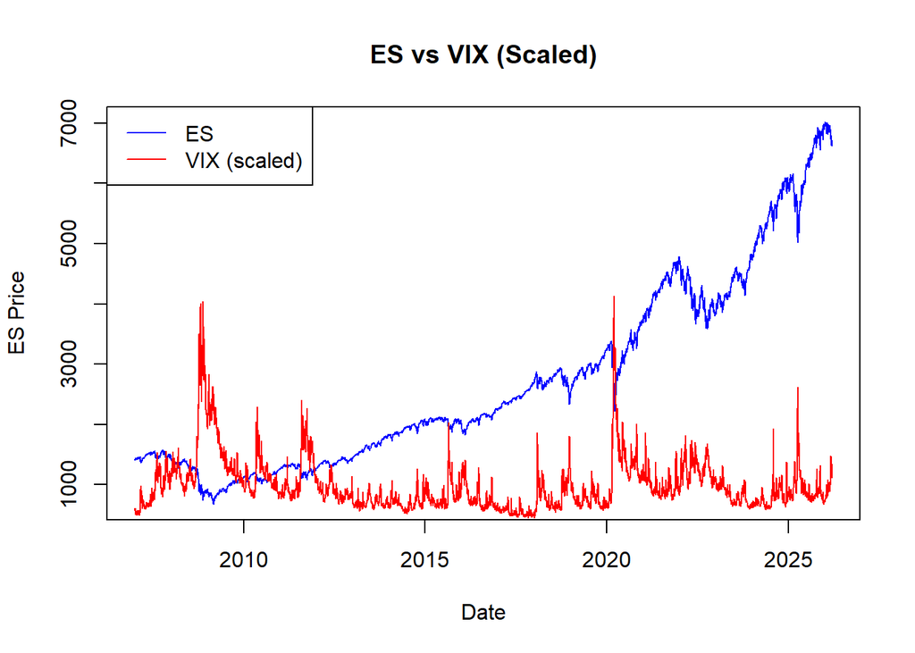

```r
plot(index(es_clean), Cl(es_clean), type = "l",
     col = "blue", xlab = "Date", ylab = "ES Price",
     main = "ES vs VIX (Scaled)")

lines(index(vix_clean), Cl(vix_clean) * 50, col = "red")

legend("topleft",
       legend = c("ES", "VIX (scaled)"),
       col = c("blue", "red"),
       lty = 1)
```

To further examine the relationship between equity prices and market volatility, the ES and VIX series were plotted together on the same chart. As the VIX operates on a much smaller scale than ES prices, it was rescaled to allow for meaningful visual comparison.

The combined plot highlights the inverse relationship between the two variables. Periods where ES prices decline are often accompanied by noticeable increases in the VIX. This is particularly evident during major market events, where volatility spikes as equity markets fall.

This visualisation reinforces the idea that ES and VIX provide complementary information. While ES reflects overall market direction, the VIX captures investor sentiment and perceived risk, making both essential for understanding market dynamics.

## Conclusion

This project analysed the relationship between equity market performance and volatility using ES futures and the VIX index. The results confirm a strong inverse relationship, where declines in market prices are typically associated with increases in volatility.

The Prophet model was effective in capturing underlying trends in both series, although its ability to predict sudden market shocks is limited. Combining ES and VIX provides a more comprehensive understanding of market conditions, as they reflect both price direction and risk.

Overall, this analysis demonstrates that time-series models such as Prophet can be valuable tools for financial forecasting, particularly when used alongside complementary indicators.

# References

- Taylor, S.J. and Letham, B. (2018). *Forecasting at Scale*. The American Statistician. (Prophet model)
- Yahoo Finance. Available at: https://finance.yahoo.com/  
  (Data source for ES futures and VIX)
- Quantmod Package Documentation. Available at: https://cran.r-project.org/package=quantmod
- Prophet Package Documentation. Available at: https://facebook.github.io/prophet/
- Chicago Board Options Exchange (CBOE). Available at: https://www.cboe.com/  
  (Information on the VIX Index)